# Portland Crime Analysis in R

Based on the excellent blog entry at - https://hautahi.com/rmaps.

```r
library(rgdal)
library(rgeos)
```

### Open shapefiles

- **dsn**- specifies the directory the shapefiles are in
- **layer** - specifies the name of the shapefile to open

```r
port <- readOGR(dsn = "data", layer = "Police_Districts_Portland")
crime <- readOGR(dsn = "data", layer = "NIJ_Nov2016_Crime")
```

### Plot some Layers

- **par** - used to specify 1 row, 2 columns. Plots will start in the 1st cell.
- **plot** - command to plot the layer. Title passed in a part of command. *cex* used to specify text weight

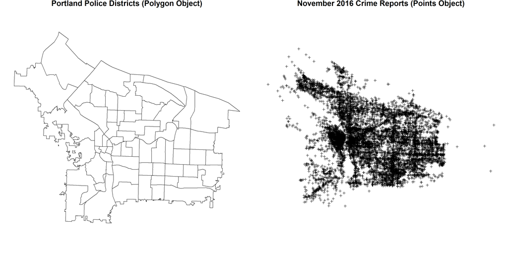

```r
par(mfrow=c(1,2), mar=c(1,1,1.2,1))
plot(port); title(main = list("Portland Police Districts (Polygon Object)", cex=1.8))
plot(crime); title(main = list("November 2016 Crime Reports (Points Object)", cex=1.8))
```

### View some info on the loaded data

- **class** - standard R command but in this case tells us what type of dataframe we have
- **summary** - command is roughly equivalent to using *ogrinfo*

Incidentally, projections in **sp** appear to be defined using standard proj4 strings. In MazamaSpatialUtils, they are specified manually uing the proj4 string:

```
SPDF@proj4string <- sp::CRS("+proj=longlat +ellps=GRS80 +datum=NAD83 +no_defs")
```

However, it is is equally easy to specify a projection by using an EPSG code:

```
epsg_4326 <- sp::CRS("+init=epsg:4326")

# Yields...
CRS arguments:
 +init=epsg:4326 +proj=longlat +datum=WGS84 +no_defs +ellps=WGS84
+towgs84=0,0,0
```

```r
class(crime)
```

```
## [1] "SpatialPointsDataFrame"
## attr(,"package")
## [1] "sp"
```

```r
summary(crime)
```

```
## Object of class SpatialPointsDataFrame
## Coordinates:
##               min     max
## coords.x1 7608809 7717689
## coords.x2  651489  727287
## Is projected: TRUE
## proj4string :
## [+proj=lcc +lat_1=44.33333333333334 +lat_2=46
## +lat_0=43.66666666666666 +lon_0=-120.5 +x_0=2500000 +y_0=0
## +ellps=GRS80 +units=ft +no_defs]
## Number of points: 16834
## Data attributes:
##                 CATEGORY           occ_date       census_tra
##  BURGLARY           :   95   2016/11/04:  645   Min.   :     0
##  MOTOR VEHICLE THEFT:  270   2016/11/03:  625   1st Qu.:  2000
##  OTHER              :13889   2016/11/05:  607   Median :  4700
##  STREET CRIMES      : 2580   2016/11/08:  607   Mean   :  6609
##                              2016/11/06:  602   3rd Qu.:  8201
##                              2016/11/01:  599   Max.   :980000
##                              (Other)   :13149
```

```r
summary(port)
```

```
## Object of class SpatialPolygonsDataFrame
## Coordinates:
##         min       max
## x 7604004.6 7701431.1
## y  651315.6  733815.4
## Is projected: TRUE
## proj4string :
## [+proj=lcc +lat_1=44.33333333333334 +lat_2=46
## +lat_0=43.66666666666666 +lon_0=-120.5 +x_0=2500000 +y_0=0
## +ellps=GRS80 +units=ft +no_defs]
## Data attributes:
##     OBJECTID   AGENCY      DISTRICT  PRECINCT
##  100    : 1   PORT:60   510    : 1   CE:20
##  101    : 1             520    : 1   EA:20
##  102    : 1             530    : 1   NO:20
##  103    : 1             540    : 1
##  104    : 1             550    : 1
##  105    : 1             560    : 1
##  (Other):54             (Other):54
```

### View bounding box of entire data layer

- **bbox()** - shows the MBR for the layer

```r
bbox(crime)
```

```
##               min     max
## coords.x1 7608809 7717689
## coords.x2  651489  727287
```

### Coordinate Reference System Info.

```r
slotNames(crime)
```

```
## [1] "data"        "coords.nrs"  "coords"      "bbox"        "proj4string"
```

```r
# 'data' 'coords.nrs' 'coords' 'bbox' 'proj4string'

proj_string <- crime@proj4string

class(proj_string)
```

```
## [1] "CRS"
## attr(,"package")
## [1] "sp"
```

```r
# 'CRS'

proj_string
```

```
## CRS arguments:
##  +proj=lcc +lat_1=44.33333333333334 +lat_2=46
## +lat_0=43.66666666666666 +lon_0=-120.5 +x_0=2500000 +y_0=0
## +ellps=GRS80 +units=ft +no_defs
```

```r
# CRS arguments:
# +proj=lcc +lat_1=44.33333333333334 +lat_2=46 +lat_0=43.66666666666666
# +lon_0=-120.5 +x_0=2500000 +y_0=0 +ellps=GRS80 +units=ft +no_defs
```

### Looking at the Data

Speaking of slots, if we want to have a look at the data itself, we grab the “data” slot.

```r
crime_data <- crime@data
head(crime_data)
```

```
##        CATEGORY   occ_date census_tra
## 1 STREET CRIMES 2016/11/01       5200
## 2 STREET CRIMES 2016/11/01       7202
## 3 STREET CRIMES 2016/11/01      10600
## 4 STREET CRIMES 2016/11/01       1101
## 5 STREET CRIMES 2016/11/01       2000
## 6 STREET CRIMES 2016/11/01       1201
```

```r
# Look at what types of crime category exist

crime_idx <- as.factor(crime@data$CATEGORY)
levels(crime_idx)
```

```
## [1] "BURGLARY"            "MOTOR VEHICLE THEFT" "OTHER"
## [4] "STREET CRIMES"
```

### Plot both data sets in the same map

In the previous plotting examples, we showed each layer in their own frame, plotted side by side. We did this by using the *par* function to split out layout pane into 2 columns, `par(mfrow=c(1,2))`. This is a useful way to see how they differ from one another, but now it’s more useful to see them together. It’s easy to do this by just plotting one layer on top of another.

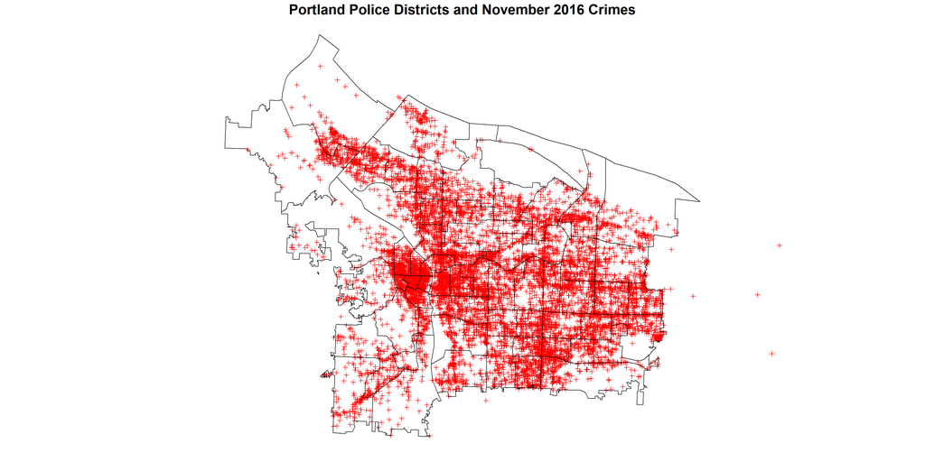

```r
par( mfrow = c(1,1), mar=c(1,1,2,1))

# Plot the district polygons first, then crime points on top. The extent of the plot window is
# set by the first layer, so if we use the points first, the top and left edges of the polygons
# will be clipped.

plot(port)
plot(crime, col= "red", add = TRUE)
plot(port, add = TRUE); title(main = list("Portland Police Districts and November 2016 Crimes", cex=1.8))
```

### Spatial Subsetting

We can see from the map above that there are crime points that fall outside the police district boundaries. These are problematic for the purpose of gathering statistics, so let’s have a look at them.

Look at the docs for rgeos: https://cran.rstudio.com/web/packages/rgeos/rgeos.pdf

Also look at spatial operation here - https://www.r-bloggers.com/clipping-spatial-data-in-r/ (shows clipping)

Good discussion of “by_id” ramifications - http://www.nickeubank.com/wp-content/uploads/2015/10/RGIS2_MergingSpatialData_part2_GeometricManipulations.html

University of Oregon examples (includes rasterizing points and regridding - http://geog.uoregon.edu/bartlein/courses/geog495/lec07.html#clippingtrimmingpoint-in-polygon-analyses

```r
# Different ways to compute intersections

length(crime)
```

```
## [1] 16834
```

```r
length(crime[port,])
```

```
## [1] 16785
```

```r
#length(raster::intersect(crime, port))

#length(gIntersection(port, crime, byid = TRUE))
```

```r
# We can use rgeos::gIntersection to get all of the points that intersect
#     inside_crime <- gIntersection(port, crime, byid = TRUE)
# but it is much, much faster to just use square-bracket subsetting.

inside_crime <- crime[port,]
```

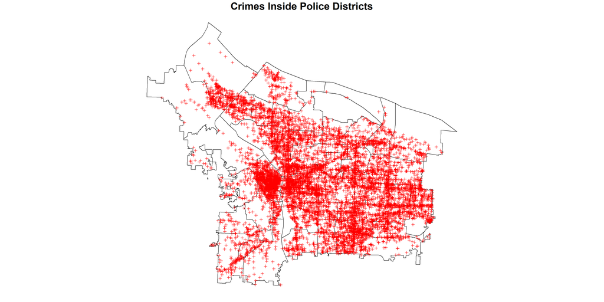

```r
par( mfrow = c(1,1), mar=c(1,1,2,1))

plot(port)
plot(inside_crime, col = "red", add = TRUE)
title(main = list("Crimes Inside Police Districts", cex=2))
```

### Selecting the points outside

How do I select just the points which fall outside the Police Districts? This is much more difficult with rgeos, as it does not work with a geometry collection. In other words, it doesn’t return a logical vector when used against multiple polygons. However, it does work when you use it against a single polygon.

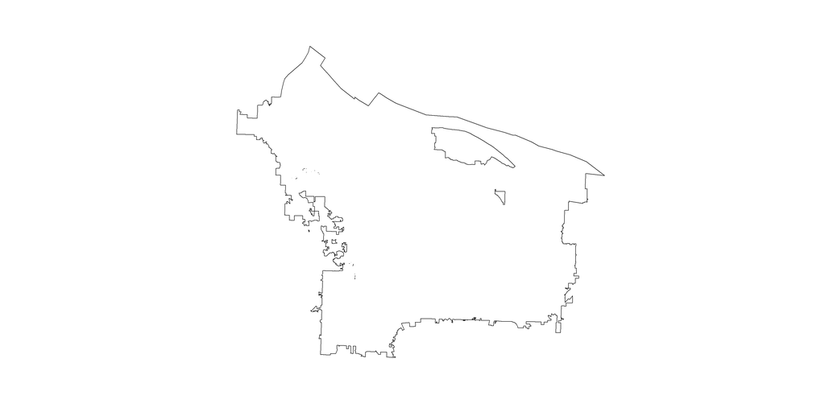

```r
# Create a single polygon for gDisjoint to work agains.

portland <- gUnaryUnion(port, id = NULL, checkValidity=NULL)
plot(portland)
```

```r
# NOTE there appears to be bad topology in this police district shapefile
```

Now we can use the `gDisjoint` function to create a logical vector of what points are outside the dissolved polygon.

```r
outside_crimes <- gDisjoint(crime, portland, byid = TRUE)
tibble::glimpse(outside_crimes)
```

```
##  logi [1, 1:16834] FALSE FALSE FALSE FALSE FALSE FALSE ...
##  - attr(*, "dimnames")=List of 2
##   ..$ : chr "1"
##   ..$ : chr [1:16834] "1" "2" "3" "4" ...
```

We convert the logical vector into an index using the `which` function and then subset using the index

```r
# Create an index of all the "TRUE" outside crimes
outside_crime_idx <- which(outside_crimes)

# Subset the outside crimes from the full crime set using their index position
my_points <- crime[outside_crime_idx,]

# Check the length
length(my_points)
```

```
## [1] 49
```

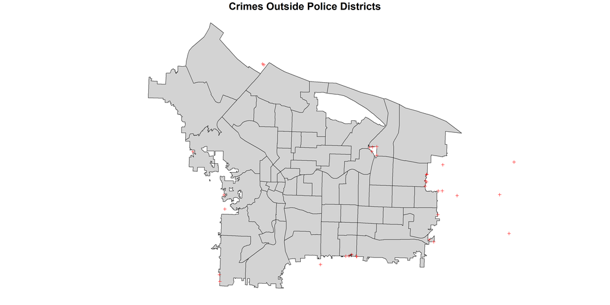

```r
par( mfrow = c(1,1), mar=c(1,1,2,1))

plot(port, col = "lightgray")
plot(my_points, col= "red", add = TRUE)
title(main = list("Crimes Outside Police Districts", cex=2))
```

```r
# NOTE: Many of the outside crimes appear to actually be very close to a police district.
# Explore whether we can do something with buffering to only exclude points which are more than
# n meters away from a district
```

Always good to verify that the the counts of “inside” + “outside” equals the total count.

```r
length(crime)
```

```
## [1] 16834
```

```r
length(inside_crime)
```

```
## [1] 16785
```

```r
length(my_points)
```

```
## [1] 49
```

```r
length(crime) == length(inside_crime) + length(my_points)
```

```
## [1] TRUE
```

What are the types of crimes in the “outside” data?

```r
unique(my_points@data$CATEGORY)
```

```
## [1] STREET CRIMES       OTHER               MOTOR VEHICLE THEFT
## [4] BURGLARY
## Levels: BURGLARY MOTOR VEHICLE THEFT OTHER STREET CRIMES
```